# Accounting for batch effects in [sleuth](http://pachterlab.github.io/sleuth/about)

Harold Pimentel

Nicolas Bray

Páll Melsted

Lior Pachter

Abstract

This walkthrough teaches the use of sleuth for analysis of experimental designs with multiple covariates via an example of conditioning on batch effect.

# Warning

This tutorial is outdated with the release of sleuth v.0.30.0, which performs gene differential expression by aggregating p-values from transcript differential expression. This tutorial will be retained here for purposes of maintaining a record, but will no longer be supported. We recommend that users switch to the updated version of sleuth.

# Introduction

This walkthrough teaches how to test for differential expression in a way that is informed by known batch effects in the data. The example uses data from the paper Bottomly et al., Evaluating Gene Expression in C57BL/6J and DBA/2J Mouse Striatum Using RNA-Seq and Microarrays, *PLoS One*, 2011. In addition to this walkthrough, data from the paper was is used for some of the analyses in the sleuth paper. The specific data that are examined in this walkthrough are 21 RNA-Seq samples from striatal samples extracted from two different mouse strains. The strains are C57BL/6J (B6) and DBA/2J (D2). The Bottomly *et al*. analysis focuses on a comparison of the RNA-Seq gene expression estimates to microarray estimates. In this walkthrough we examine in detail how to analyze the RNA-Seq.

The walkthrough is self-contained, but new users to sleuth will benefit from first studying the Trapnell *et al*. walkthrough which demonstrates the use of sleuth on a simple two condition experiment. This walkthrough, in addition to illustrating how to condition on batch effects, provides an example for how to use sleuth for analyses of experimental designs with multiple covariates. The tutorial also moves beyond the isoform-level analysis of the Trapnell *et al*. walkthrough and illustrates how to perform gene-level analysis.

# Preliminaries

Create a directory for the analysis and start up `R`. Set the working directory with the `setwd()` command.

Requirements for this walkthrough:

- knowledge of [how to use sleuth for simple two condition experiments](https://pachterlab.github.io/sleuth/walkthroughs/trapnell).
- `cowplot` for making prettier plots and plots with grids. Available in CRAN: `install.packages('cowplot')`.
- `biomaRt` for extracting the Ensembl transcript to gene mapping. For alternative methods, please see this walk-through.

To install the package:

```r
source("https://bioconductor.org/biocLite.R")
biocLite("biomaRt")
```

- The walthrough begins after the RNA-Seq samples have been quantified with kallisto. While kallisto is very fast in quantifying samples, downloading the raw data from the short read archive is time consuming. kallisto quantifications are therefore directly downloadable for the relevant samples using

```bash
wget -O ../Bottomly_results.zip 'https://www.dropbox.com/s/gnbnkuup3pdfenk/Bottomly_results.zip?dl=1'
unzip ../Bottomly_results.zip -d ..
```

Let’s load the requisite packages:

```r
suppressMessages({
  library('cowplot')
  library('sleuth')
})
```

## Parsing metadata

A sleuth analysis is dependent on a metadata file, which describes the experimental design, the sample names, conditions and covariates. The metadata file is external to sleuth, and must be prepared prior to analysis. The first step in a sleuth analysis is loading of the metadata file:

```r
metadata <- read.csv('../metadata/experiment.csv', stringsAsFactors = FALSE)
```

```r
head(metadata, n = 20)
```

```
##    experiment_ID run_ID run_accession library_strategy library_name
## 1         377905 449917     SRR099223            OTHER   D2_1_4_lib
## 2         377906 449918     SRR099224            OTHER   D2_2_4_lib
## 3         377907 449919     SRR099225            OTHER   D2_3_4_lib
## 4         377908 449920     SRR099226            OTHER   D2_5_4_lib
## 5         377909 449921     SRR099227            OTHER   B6_6_4_lib
## 6         377910 449922     SRR099228            OTHER   B6_7_4_lib
## 7         377911 449923     SRR099229            OTHER   B6_8_4_lib
## 8         377912 449924     SRR099230            OTHER   B6_1_6_lib
## 9         377913 449925     SRR099231            OTHER   B6_2_6_lib
## 10        377914 449926     SRR099232            OTHER   B6_3_6_lib
## 11        377915 449927     SRR099233            OTHER   B6_5_6_lib
## 12        377916 449928     SRR099234            OTHER   D2_6_6_lib
## 13        377917 449929     SRR099235            OTHER   D2_7_6_lib
## 14        377918 449930     SRR099236            OTHER   D2_8_6_lib
```

[output cut: 27 more lines]

```r
extract_metadata <- function(library_name) {
  ret <- lapply(strsplit(library_name, '_'),
    function(x) {
      data.frame(strain = x[1], experiment = x[2], lane = x[3],
        stringsAsFactors = FALSE)
    })
  dplyr::bind_rows(ret)
}

metadata <- dplyr::select(metadata, -strain)
metadata <- dplyr::bind_cols(metadata, extract_metadata(metadata$library_name))
metadata <- dplyr::select(metadata, run_accession, library_name, strain,
  experiment, lane)
```

Finally, we add the path names of the kallisto output directories to the metadata table:

```r
metadata <- dplyr::mutate(metadata,
  path = file.path('..', 'results', run_accession, 'kallisto'))
head(metadata)
```

```
##   run_accession library_name strain experiment lane
## 1     SRR099223   D2_1_4_lib     D2          1    4
## 2     SRR099224   D2_2_4_lib     D2          2    4
## 3     SRR099225   D2_3_4_lib     D2          3    4
## 4     SRR099226   D2_5_4_lib     D2          5    4
## 5     SRR099227   B6_6_4_lib     B6          6    4
## 6     SRR099228   B6_7_4_lib     B6          7    4
##                            path
## 1 ../results/SRR099223/kallisto
## 2 ../results/SRR099224/kallisto
## 3 ../results/SRR099225/kallisto
## 4 ../results/SRR099226/kallisto
## 5 ../results/SRR099227/kallisto
## 6 ../results/SRR099228/kallisto
```

It is important to spot check the metadata file again to make sure that the kallisto runs correspond to the accession numbers in the table, so that each row is associated with the correct sample.

```r
metadata <- dplyr::rename(metadata, sample = run_accession)
```

## Associating transcripts to genes

The sample quantifications performed by kallisto have produced transcript abundance and count estimates. These have been parsed by sleuth in the steps just performed, however sleuth does not “know” about genes yet. To perform gene-level analysis sleuth must parse a gene annotation. One easy way to do this is using biomaRt and Ensembl:

```r
mart <- biomaRt::useMart(biomart = "ENSEMBL_MART_ENSEMBL",
  dataset = "mmusculus_gene_ensembl",
  host = "dec2015.archive.ensembl.org")
  # host = "ensembl.org")
ttg <- biomaRt::getBM(
  attributes = c("ensembl_transcript_id", "transcript_version",
  "ensembl_gene_id", "external_gene_name", "description",
  "transcript_biotype"),
  mart = mart)
ttg <- dplyr::rename(ttg, target_id = ensembl_transcript_id,
  ens_gene = ensembl_gene_id, ext_gene = external_gene_name)
head(ttg)
```

```
##            target_id transcript_version           ens_gene ext_gene
## 1 ENSMUST00000082423                  1 ENSMUSG00000064372    mt-Tp
## 2 ENSMUST00000082422                  1 ENSMUSG00000064371    mt-Tt
## 3 ENSMUST00000082421                  1 ENSMUSG00000064370  mt-Cytb
## 4 ENSMUST00000082420                  1 ENSMUSG00000064369    mt-Te
## 5 ENSMUST00000082419                  1 ENSMUSG00000064368   mt-Nd6
## 6 ENSMUST00000082418                  1 ENSMUSG00000064367   mt-Nd5
##                                                                       description
## 1         mitochondrially encoded tRNA proline [Source:MGI Symbol;Acc:MGI:102478]
## 2       mitochondrially encoded tRNA threonine [Source:MGI Symbol;Acc:MGI:102473]
## 3         mitochondrially encoded cytochrome b [Source:MGI Symbol;Acc:MGI:102501]
## 4   mitochondrially encoded tRNA glutamic acid [Source:MGI Symbol;Acc:MGI:102488]
## 5 mitochondrially encoded NADH dehydrogenase 6 [Source:MGI Symbol;Acc:MGI:102495]
## 6 mitochondrially encoded NADH dehydrogenase 5 [Source:MGI Symbol;Acc:MGI:102496]
##   transcript_biotype
## 1            Mt_tRNA
## 2            Mt_tRNA
## 3     protein_coding
## 4            Mt_tRNA
## 5     protein_coding
## 6     protein_coding
```

The resulting table contains Ensembl gene names (column 3) and the associated transcripts (column 1). Note that the gene-transcript mapping must be compatible with the transcriptome used with kallisto. In other words, to use Ensembl transcript-gene associations kallisto was run using the Ensembl transcriptome.

# Preparing the analysis

The next step is to build a sleuth object. The sleuth object contains specification of the experimental design, the full model to be estimated from the data, a map describing grouping of transcripts into genes (or other groups), and a number of user specific parameters. In the example that follows, `metadata` is the experimental design, `~strain` specifies the full model to be estimated, and `target_mapping` describes the transcript groupings into genes previously constructed:

```r
so <- sleuth_prep(metadata, target_mapping = ttg,
  aggregation_column = 'ens_gene', extra_bootstrap_summary = TRUE)
```

```
## reading in kallisto results
```

```
## dropping unused factor levels
```

```
## .....................
```

```
## normalizing est_counts
```

```
## 45143 targets passed the filter
```

```
## normalizing tpm
```

```
## merging in metadata
```

```
## aggregating by column: ens_gene
```

```
## 16586 genes passed the filter
```

```
## Warning in sleuth_prep(metadata, target_mapping = ttg, aggregation_column = "ens_gene", : 518 target_ids are missing annotations for the aggregation_column: ens_gene.
## These target_ids will be dropped from the gene-level analysis.
## If you did not expect this, check your 'target_mapping' table for missing values.
```

```
## summarizing bootstraps
```

Notice the warning: “518 target_ids are missing annotations for the aggregation_column: ens_gene.” This means that there are transcripts that do not have a gene mapping. This is pretty common in most annotations. However, if this number is very high, it is advisable to consider using another transcript-to-gene mapping or another annotation.

# The naïve analysis

As discussed in the Trapnell *et al*. walkthough, to identify genes differential between two conditions two models must be fit by sleuth. The first is known as the reduced model, and in this case we name the “intercept model”. It fits a single parameter for each gene thereby enforcing equal abundances between conditions. The second model is known as the full model, and it includes a parameter that is strain dependent. We call it the “strain model”. With the likelihood ratio test sleuth identifies genes whose abundances are significantly better explained when strain is taken into account. The mechanics of the fitting are:

```r
so <- sleuth_fit(so, ~1, 'intercept')
```

```
## fitting measurement error models
```

```
## shrinkage estimation
```

```
## computing variance of betas
```

```r
so <- sleuth_fit(so, ~strain, 'strain')
```

```
## fitting measurement error models
```

```
## shrinkage estimation
```

```
## computing variance of betas
```

The likelihood ratio test (lrt) is performed with

```r
so <- sleuth_lrt(so, 'intercept', 'strain')
```

Significantly differential genes are extracted with the commands

```r
sleuth_table_strain <- sleuth_results(so, 'intercept:strain', 'lrt', show_all = FALSE)
sleuth_significant_strain <- dplyr::filter(sleuth_table_strain, qval <= 0.05)
```

The most significantly differential genes are

```r
head(sleuth_significant_strain, 20)
```

```
##             target_id test_stat         pval         qval       rss
## 1  ENSMUSG00000066553 109.14421 1.508982e-25 2.500987e-21 175.99913
## 2  ENSMUSG00000066878 106.16928 6.769792e-25 5.610127e-21 214.41286
## 3  ENSMUSG00000083879 100.00885 1.517177e-23 8.381896e-20 150.46165
## 4  ENSMUSG00000050550  90.44042 1.906320e-21 7.898839e-18 143.80255
## 5  ENSMUSG00000082100  89.75722 2.692541e-21 8.925234e-18  97.78144
## 6  ENSMUSG00000078480  85.30594 2.555940e-20 7.060359e-17 109.03477
## 7  ENSMUSG00000078684  79.33450 5.243598e-19 1.241534e-15  14.50666
## 8  ENSMUSG00000084403  78.88760 6.574600e-19 1.362093e-15 126.24617
## 9  ENSMUSG00000074479  78.24882 9.084522e-19 1.672965e-15 141.92678
## 10 ENSMUSG00000100801  77.16306 1.574102e-18 2.371743e-15 176.30392
## 11 ENSMUSG00000102742  77.18085 1.559990e-18 2.371743e-15  11.13463
## 12 ENSMUSG00000023764  76.19593 2.568709e-18 3.547816e-15  15.63018
## 13 ENSMUSG00000083375  75.56961 3.527495e-18 4.497285e-15  89.97944
## 14 ENSMUSG00000093909  73.83203 8.505522e-18 1.006932e-14  18.72559
```

[output cut: 48 more lines]

To confirm that the differential analysis is working it’s important to examine specific genes in detail. For example, the most significantly differential gene that emerges from the analysis above is [ENSMUSG00000066553](http://www.ensembl.org/Mus_musculus/Gene/Summary?g=ENSMUSG00000066553;r=12:24638669-24639010;t=ENSMUST00000140065)(a processed pseudogene), whose abundances in the different samples can be viewed with

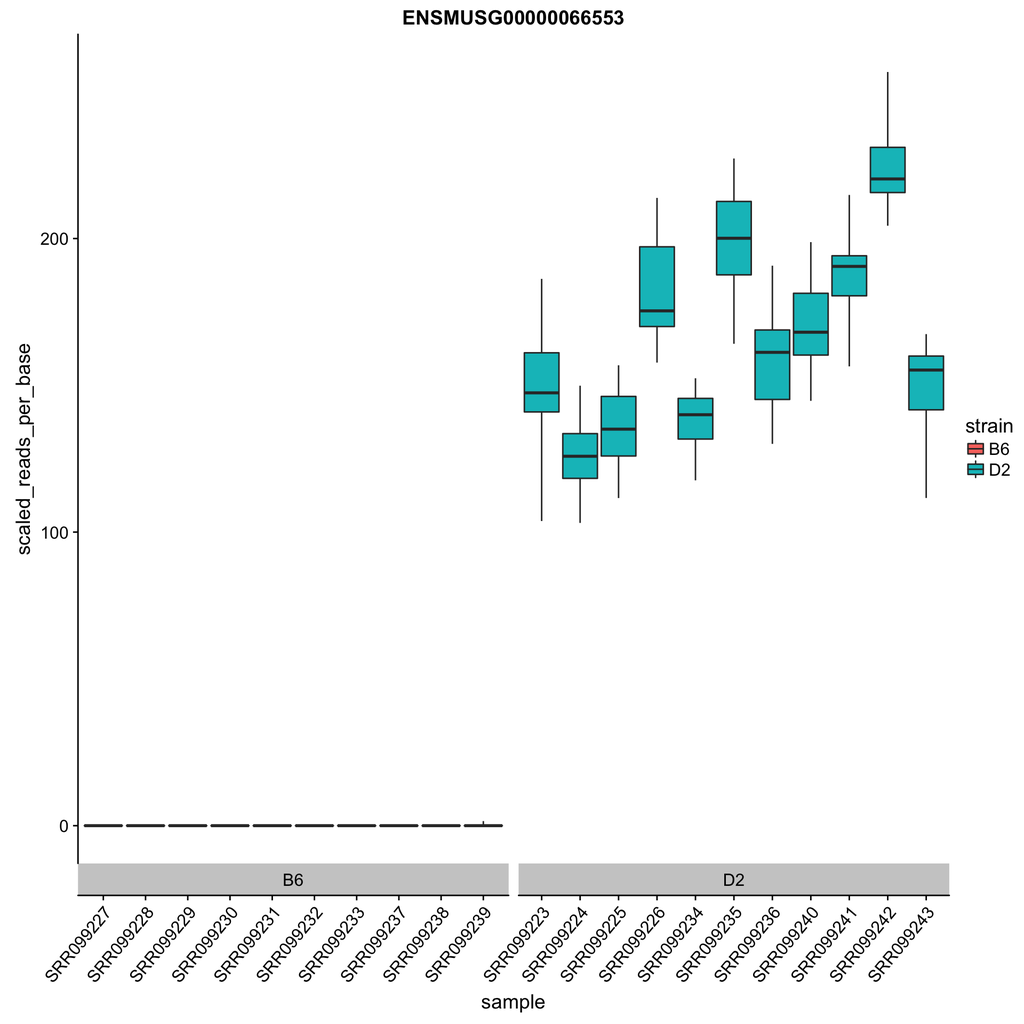

```r
plot_bootstrap(so, "ENSMUSG00000066553",
  units = "scaled_reads_per_base", color_by = "strain")
```

However visualization of individual gene abundances is not sufficient to fully quality control an experiment. A principal component analysis (PCA) of the kallisto abundances shows that while the samples appear to be clustered into a few distinct groups, they are not well-separated by strain.

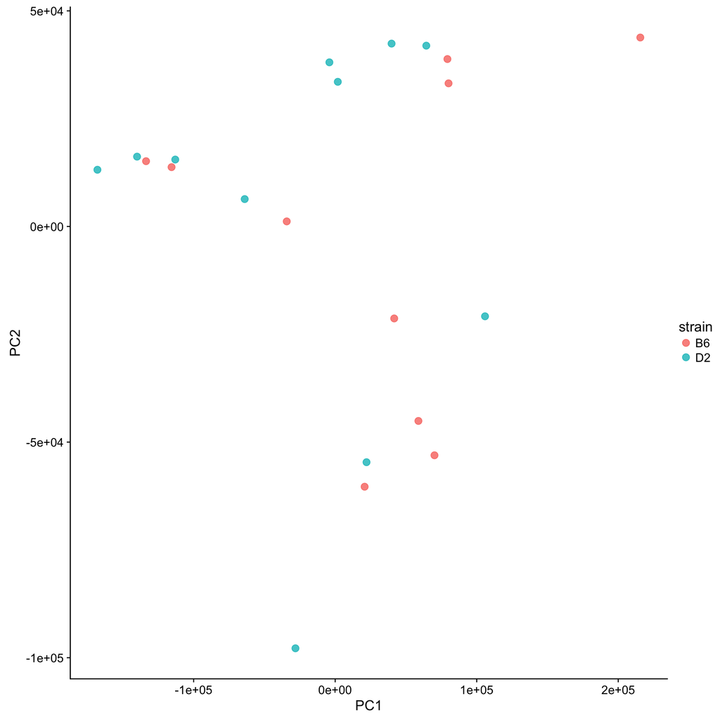

```r
plot_pca(so, color_by = 'strain')
```

The source of the clustering is revealed by coloring the samples by “lane” instead:

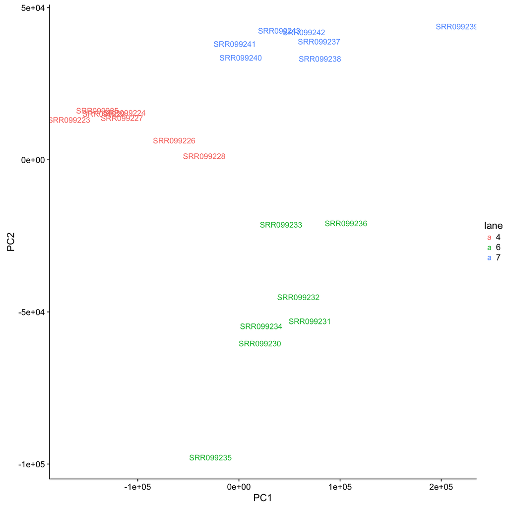

```r
plot_pca(so, color_by = 'lane', text_labels = TRUE)
```

This batch effect is problematic, as genes might be identified as differential in the strain analysis merely because they were sequenced on different lanes.

# Batch analysis

To test whether this is in fact the case, the test described above can be repeated with the full model comprising a paramter for “lane” instead of “strain”.

```r
so <- sleuth_fit(so, ~lane, 'lane')
```

```
## fitting measurement error models
```

```
## shrinkage estimation
```

```
## computing variance of betas
```

The likelihood ratio test is performed as before except with the lane model

```r
so <- sleuth_lrt(so, 'intercept', 'lane')
```

The differential analysis test now reveals genes most affected by batch:

```r
sleuth_table_lane <- sleuth_results(so, 'intercept:lane', 'lrt', show_all = FALSE)
sleuth_significant_lane <- dplyr::filter(sleuth_table_lane, qval <= 0.05)
head(sleuth_significant_lane, 20)
```

```
##             target_id test_stat         pval         qval       rss
## 1  ENSMUSG00000035202  56.29129 5.977255e-13 5.840197e-09 16.152354
## 2  ENSMUSG00000089855  55.96189 7.047420e-13 5.840197e-09 61.039496
## 3  ENSMUSG00000020889  53.27497 2.700771e-12 1.492086e-08  4.556221
## 4  ENSMUSG00000039713  47.53651 4.759683e-11 1.972175e-07  3.747196
## 5  ENSMUSG00000043165  46.74458 7.072006e-11 2.344229e-07  8.984117
## 6  ENSMUSG00000073867  46.20006 9.285045e-11 2.564839e-07 19.442089
## 7  ENSMUSG00000017478  43.81815 3.054991e-10 7.233347e-07  1.989675
## 8  ENSMUSG00000001227  42.54826 5.764518e-10 1.061568e-06  2.037432
## 9  ENSMUSG00000025290  42.66373 5.441135e-10 1.061568e-06  1.705092
## 10 ENSMUSG00000045045  42.12655 7.117636e-10 1.179677e-06  2.348010
## 11 ENSMUSG00000034863  41.76647 8.521692e-10 1.283987e-06  1.951154
## 12 ENSMUSG00000006517  41.39228 1.027496e-09 1.377085e-06  2.451450
## 13 ENSMUSG00000038146  41.29237 1.080132e-09 1.377085e-06  1.281663
## 14 ENSMUSG00000096232  41.07331 1.205157e-09 1.426734e-06  4.265125
```

[output cut: 48 more lines]

To identify genes that are truly differential between strain, it is therefore necessary to fit and account for the (lane) batch effect.

## Fitting a model that acounts for batch

To account for batch while testing for strain differences, the full model must include parameters for both lane and strain.

```r
so <- sleuth_fit(so, ~lane + strain, 'full')
```

```
## fitting measurement error models
```

```
## shrinkage estimation
```

```
## computing variance of betas
```

The reduced model must still include a parameter for the lane. In this way, the strain differences are accounted for while conditioning on the lane. This model, the “lane model” has already been fit. So the likelihood ratio test can now be applied as before:

```r
so <- sleuth_lrt(so, 'lane', 'full')
sleuth_table <- sleuth_results(so, 'lane:full', 'lrt', show_all = FALSE)
sleuth_significant <- dplyr::filter(sleuth_table, qval <= 0.05)
head(sleuth_significant, 20)
```

```
##             target_id test_stat         pval         qval        rss
## 1  ENSMUSG00000066553 112.81226 2.372041e-26 3.932844e-22 172.747546
## 2  ENSMUSG00000066878 109.16895 1.490261e-25 1.235426e-21 210.366186
## 3  ENSMUSG00000083879 103.51431 2.585203e-24 1.428755e-20 146.504050
## 4  ENSMUSG00000050550  95.24126 1.685409e-22 6.986020e-19 140.677170
## 5  ENSMUSG00000082100  92.45331 6.893198e-22 2.285784e-18  94.707519
## 6  ENSMUSG00000078480  88.33270 5.532129e-21 1.214658e-17 105.257016
## 7  ENSMUSG00000078684  88.64366 4.727385e-21 1.214658e-17  14.073879
## 8  ENSMUSG00000084403  88.21853 5.860835e-21 1.214658e-17 121.524895
## 9  ENSMUSG00000102742  85.00888 2.970287e-20 5.471929e-17  10.898801
## 10 ENSMUSG00000074479  84.69997 3.472564e-20 5.757511e-17 137.548892
## 11 ENSMUSG00000100801  83.25766 7.202596e-20 1.085628e-16 169.294196
## 12 ENSMUSG00000083833  80.09380 3.570518e-19 4.553784e-16 204.689110
## 13 ENSMUSG00000094497  80.09380 3.570518e-19 4.553784e-16 204.689110
## 14 ENSMUSG00000083375  79.94697 3.845944e-19 4.554696e-16  88.391272
```

[output cut: 48 more lines]

While the top 8 genes are the same as in the naïve analysis, differences start to emerge afterwards. Furthermore, the top genes emerge as more significantly differential when conditioning on batch.

## Comparing the results

This is a simple comparison just to show how the rankings differ.

First, we create a new column for the relative rank within both lists.

```r
tmp <- dplyr::inner_join(
  dplyr::mutate(
    dplyr::select(sleuth_significant, target_id, qval_batch = qval),
    rank_batch = 1:length(qval_batch)),
  dplyr::mutate(
    dplyr::select(sleuth_significant_strain, target_id, qval_strain = qval),
    rank_strain = 1:length(qval_strain))
  ,
  by = 'target_id')
```

Next, we compute the relative difference between the ranks.

```r
tmp <- dplyr::mutate(tmp,
  relative_difference = abs(rank_batch - rank_strain) / (rank_batch + rank_strain))
```

Finally, we can plot a few of the top different results:

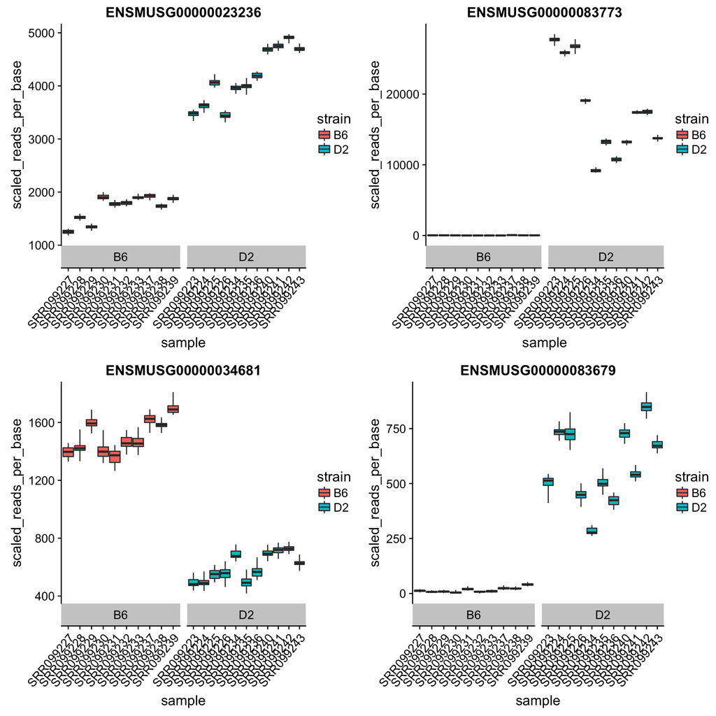

```r
top_different <- dplyr::arrange(head(tmp, 100), desc(relative_difference))
p <- lapply(top_different$target_id[1:4],
  function(x) {
    plot_bootstrap(so, x, color_by = 'strain')
  })
plot_grid(plotlist = p)
```

## Comparing effect sizes

We can extract all of the parameters using the `extract_model` function by supplying the model name used in the `sleuth_fit` call.

```r
full_model <- extract_model(so, 'full')
strain_model <- extract_model(so, 'strain')
```

Next, if we wish to compare the values we can do so. Note that these values are conditional on the other parameters being in the model.

```r
effect_sizes <- dplyr::inner_join(
  dplyr::select(dplyr::filter(full_model, grepl('strain', term)),
    target_id, full_estimate = estimate),
  dplyr::select(dplyr::filter(strain_model, grepl('strain', term)),
    target_id, strain_estimate = estimate),
  by = 'target_id'
  )
dplyr::inner_join(
  dplyr::select(top_different[1:10, ], target_id),
  effect_sizes,
  by = 'target_id')
```

```
##             target_id full_estimate strain_estimate
## 1  ENSMUSG00000023236     0.9027237       0.8943847
## 2  ENSMUSG00000083773     7.8765147       8.1633951
## 3  ENSMUSG00000034681    -0.9342490      -0.9273350
## 4  ENSMUSG00000083679     3.6483276       3.7100737
## 5  ENSMUSG00000028393     1.2441801       1.2762812
## 6  ENSMUSG00000067274    -1.2279081      -1.1848001
## 7  ENSMUSG00000083833     6.2394707       6.3232645
## 8  ENSMUSG00000024026     0.6202759       0.6250761
## 9  ENSMUSG00000094497     6.2394707       6.3232645
## 10 ENSMUSG00000020415    -2.3295447      -2.3468443
```

There is not much to say other than they are different.